# Clustering different heights of the worldwide Highest Ollie contest

Ben M

1/22/2017

## Skate-aid Worldwide Highest Ollie Contest 2017

On 7th January 2017, [Skate-aid](http://www.skate-aid.org) organised a competition which involved the contestant(s). Jumping over an adjustable obstacle by Ollieing especially where they have established projects namely:

- Copenhagen, Denmark (DK)
- Cape Town, South Africa (ZA)
- Münster, Germany (DE)
- Nairobi, Kenya (KE)
- San Isidro, Costa Rica (CR)
- Dodoma, Tanzania (TZ)
- Bethlehem, Palestine (PS)
- Kigali, Rwanda (RW)
- Kampala,Uganda (UG)
- La Paz,Bolivia (BO)

[Photo by Robert Opiyo, skateboarder Sydney Yongo](https://www.facebook.com/photo.php?fbid=1572448036103794&set=a.406576599357616.113391.100000158393836&type=3&theater)

‘The aim of the contest was to unite skaters from all over the world and to help at-risk youths with a safe and constructive space that children require in their developmental ages.’ [From page Skate-aid Shangilia Skatepark Nairobi - Kenya](https://www.facebook.com/skateparknairobi/photos/a.622418004449939.1073741827.622414867783586/1423265004365231/?type=3&theater)

From the results of the competition. Which i acquired using this link [results](https://www.facebook.com/skateaid/posts/1379140678786498). Here are the results.

1. Copenhagen: Alexander Risrad - 103 cm (highest record)
2. Cape Town: Ryan Naidoo -99 cm
3. Münster: Georg G Anders -85 cm
4. Nairobi: Kevin Maina - 75 cm
5. San Isidro: William Morales -70 cm
6. Dodoma: Gideon -54cm
7. Bethlehem: Moyyed and Anas- 20 cm (Under 15 only)
8. Kigali: 15cm (under 15 only)
9. Uganda: from John Ray’s post here [facebook post](https://www.facebook.com/search/top/?init=quick&q=highest%20ollie%20uganda&tas=0.20332534655961598)

cm- Centimeters in height.

I changed the results a bit so that they could be accomodated in the graph i’ve drawn below. Notice the changes in the lines of code below.

## Making the dataframe

```r
# making a dataframe of the results of the contest
ctry <- c('DK','ZA','DE','KE','CR','TZ','UG','PS','RW','US') #different countries
hts <- c(103,99,85,75,70,54,88.4,20,15,114.3) # heights are in centimetres
names <- c('A.Risrad(103)','R.Naidoo(99)','G.Anders(85)','K.Maina(75)','W.Morales(70)','Gideon(54)','Peter(88.4)','Moyyed & Anas(20)','Na.RW(15)','A.Garcia(114.3)')
df <- data.frame(ctry,hts,names)
df
```

```
##    ctry   hts             names
## 1    DK 103.0     A.Risrad(103)
## 2    ZA  99.0      R.Naidoo(99)
## 3    DE  85.0      G.Anders(85)
## 4    KE  75.0       K.Maina(75)
## 5    CR  70.0     W.Morales(70)
## 6    TZ  54.0        Gideon(54)
## 7    UG  88.4       Peter(88.4)
## 8    PS  20.0 Moyyed & Anas(20)
## 9    RW  15.0         Na.RW(15)
## 10   US 114.3   A.Garcia(114.3)
```

## Drawing the plot(dendogram)

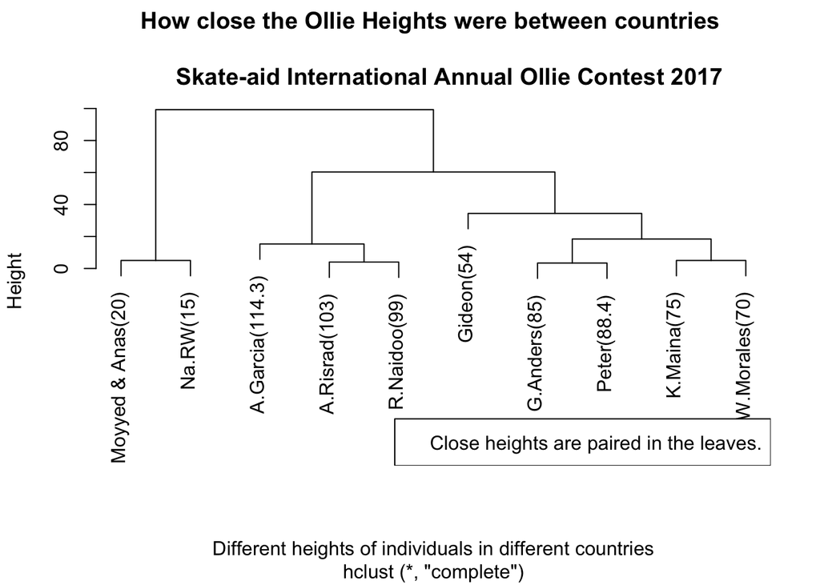

```r
# Make hierarichal clustering object and visualize
dist_mat <- dist(df[,2]) # selecting the second column
hc <- hclust(dist_mat)
plot(hc, labels = df$names, xlab = "Different heights of individuals in different countries", main = "How close the Ollie Heights were between countries \n
     Skate-aid International Annual Ollie Contest 2017")
legend(x = "bottomright", legend = "Close heights are paired in the leaves.")
```

## Interpretation

The graph you’ve seen above puts the Ollie heights together with the ones most closest being in the same leaf. That is, **Moyyes & Anas** and **Na.RW** (i named it like that because the name of the person was missing and i didn’t find it anywhere). In addition, the heights of **A.Risrad** and **R.Naidoo** are really close to each other. Notice i also added the [Guinness world record](http://www.guinnessworldrecords.com/world-records/skateboarding-highest-ollie-) as well for comparison.

## Conclusion

**A.Garcia** still holds the world record from Las Vegas, United States in 2011. But, if more practice & learning from mistakes could be used by **A.Risrad** and **R.Naidoo** the record could be beat as an example. Now, you know whose Ollie height was close to whom. Question is, where would yours be among these heights? Thanks for reading!

## References

[Text Mining course on Datacamp: Distance matrix and Dendrogram](https://campus.datacamp.com/courses/intro-to-text-mining-bag-of-words/adding-to-your-tm-skills?ex=3)

[Data Visualization in R course on Datacamp: Adding details to plots](https://www.datacamp.com/courses/data-visualization-in-r)